# STS 112: Lab 9

James Chapman

Load the `tidyverse` package and read in the Week 9 data.

```r
library(tidyverse)
```

```r
acs = read_csv("acs_2014.csv")
```

# Table 1

Create the `RACETH` variable for Table 1 just as you did in the notebook and save it as a new data frame called `table1` (you can copy and paste your code from the notebook). Test your new variable.

```r
table1 <- acs %>% mutate(RACETH = ifelse(HISPAN > 0, 0, RACESING)) %>%
                  filter(RACESING < 5) %>%
                  mutate(RACETH = factor(RACETH, labels = c("Hispanic", "NH White", "NH Black", "NH Native", "NH Asian/Pacific")))

#Test!
table(table1$RACETH, table1$RACESING)
```

```
                         1       2       3       4
  Hispanic          417699   13525    6288    3755
  NH White         2145305       0       0       0
  NH Black               0  345844       0       0
  NH Native              0       0   31052       0
  NH Asian/Pacific       0       0       0  163551
```

```r
table(table1$RACETH, table1$HISPAN)
```

```
                         0       1       2       3       4
  Hispanic               0  283403   41480   17623   98761
  NH White         2145305       0       0       0       0
  NH Black          345844       0       0       0       0
  NH Native          31052       0       0       0       0
  NH Asian/Pacific  163551       0       0       0       0
```

Make separate tables for potential wives and potential husbands, then join them together in a data frame called `couples`. This is exactly what we did in Notebook 9, but here I want you to do it in the most streamlined way possible, without the extraneous code I included for teaching purposes. Keep only the variables you will need for analysis and rename `RACETH` to `WRACETH` for wives and `HRACETH` for husbands. **Be sure to test each step and comment your code to explain what you are doing.**

```r
#Filter only people in their first marriage, currently married, and married within the last 5 years.
table1 <- table1 %>% filter(MARRNO == 1 & MARST == 1 & (YEAR - YRMARR) <= 5)

#Test that we have removed all the necessary people.
table1 %>% filter(MARRNO != 1 | MARST != 1 | (YEAR - YRMARR) > 5)
```

| YEAR | SERIAL | METRO | PERNUM | PERWT | MOMLOC | POPLOC | SPLOC | NCHILD | RELATE | RELATED | SEX | AGE | MARST | MARRNO | YRMARR | FERTYR | RACE | RACED | HISPAN | HISPAND | BPL | BPLD | RACESING | RACESINGD | EDUC | EDUCD | RACETH |
| --- | --- | --- | --- | --- | --- | --- | --- | --- | --- | --- | --- | --- | --- | --- | --- | --- | --- | --- | --- | --- | --- | --- | --- | --- | --- | --- | --- |

```r
#Create a new dataframe for wives aged 20 to 39 and rename their RACETH variable.
wives <- table1 %>% filter(SEX == 2 & AGE %in% 20:39) %>% rename(WRACETH = RACETH)

#Test that we have  removed all the necessary people from the wives dataframe.
wives %>% filter(SEX !=2 | !(AGE %in% 20:39))
```

| YEAR | SERIAL | METRO | PERNUM | PERWT | MOMLOC | POPLOC | SPLOC | NCHILD | RELATE | RELATED | SEX | AGE | MARST | MARRNO | YRMARR | FERTYR | RACE | RACED | HISPAN | HISPAND | BPL | BPLD | RACESING | RACESINGD | EDUC | EDUCD | WRACETH |
| --- | --- | --- | --- | --- | --- | --- | --- | --- | --- | --- | --- | --- | --- | --- | --- | --- | --- | --- | --- | --- | --- | --- | --- | --- | --- | --- | --- |

```r
#Create a new dataframe for husbands and rename their RACETH variable. Remove all unnecessary variables.
husbands <- table1 %>% filter(SEX == 1) %>% rename(HRACETH = RACETH) %>% select(HRACETH, SERIAL, PERNUM)

#Test that we have  removed all the necessary variables from the husbands dataframe.
names(husbands)
```

```
[1] "HRACETH" "SERIAL"  "PERNUM"
```

```r
#Join the two dataframes together.
couples <- inner_join(wives, husbands, by = c("SERIAL", "SPLOC" = "PERNUM")) %>% select(FERTYR, WRACETH, HRACETH, PERWT)

names(couples)
```

```
[1] "FERTYR"  "WRACETH" "HRACETH" "PERWT"
```

Now make a heat map showing the **percentage** of couples with each combination of husband race/ethnicity and wife race/ethnicity had a baby in each year. The numbers you calculated in the Table 1 section of Notebook 9 will be the denominators. The numerators will be the number of couples in each group that had a baby in the last year. You will need to start by figuring out which variable indicates that a couple had a baby in the last year and then make a new logical variable for each couple that is `TRUE` if the couple had a baby in the last year and `FALSE` otherwise, just as you did in Lab 7 for people who were born in the South. Make sure that your titles and labels are correct.

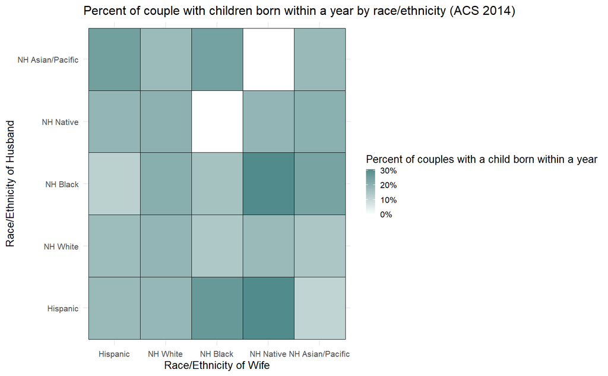

```r
couples %>% mutate(CHILD = FERTYR == 2) %>%
            group_by(WRACETH, HRACETH) %>%
            count(CHILD, wt = PERWT) %>%
            mutate(TOTAL = sum(n)) %>%
            filter(CHILD == TRUE) %>%
            mutate(PCT.CHILD  = n/TOTAL) %>%
            #Add missing rows & change the missing values to N/A
            group_by(WRACETH) %>% complete(HRACETH) %>% ungroup() %>% mutate(PCT.CHILD = ifelse(is.na(PCT.CHILD), 0, PCT.CHILD)) %>%
            #Heatmap
            ggplot(aes(x = WRACETH, y = HRACETH, fill = PCT.CHILD)) + geom_tile(color = "black") +
            scale_fill_gradient(low = "white", high = "darkslategray4", labels = scales::percent) +
            theme_minimal(base_size = 20) +
            labs(x = "Race/Ethnicity of Wife", y = "Race/Ethnicity of Husband", fill = "Percent of couples with a child born within a year", title = "Percent of couple with children born within a year by race/ethnicity (ACS 2014)")
```

# Table 2

Now prepare your data for Table 2. We are going to make the same `RACETH` variable that we made for Table 2 in the notebook, but this time we don’t need an indicator of whether the person is biracial. Instead, we need an indicator of each person’s sex and whether or not they are a householder (head of household or person 1). These should be factor variables with informative labels. Create a new data frame called `table2` that includes the Table 2 version of `RACETH` and the two indicators. Test these new variables.

```r
table2 <- acs %>% mutate(RACETH = ifelse(HISPAN > 0, 0,
                                  ifelse(RACE == 1, 1,
                                  ifelse(RACE == 2 | RACED == 801, 2,
                                  ifelse(RACE == 3 | RACED == 802, 3,
                                  ifelse(RACE %in% 4:6 | RACED %in% 810:823, 4, 5)))))) %>%
                  filter(RACETH < 5) %>%
                  mutate(RACETH = factor(RACETH, labels = c("Hispanic", "NH White", "NH Black", "NH Native", "NH Asian/Pacific"))) %>%
                  mutate(SEXF = factor(SEX, labels = c("Male", "Female"))) %>%
                  mutate(HHOLDER = RELATE == 1) %>%
                  mutate(HHOLDER = factor(HHOLDER, labels = c("Not Householder", "Householder")))

#Test
table(table2$RACED, table2$RACETH)
```

```
      Hispanic NH White NH Black NH Native NH Asian/Pacific
  100   294697  2106566        0         0                0
  200     9348        0   323722         0                0
  302      210        0        0       692                0
  303       27        0        0       302                0
  304      151        0        0      3007                0
  305       10        0        0       139                0
  306       10        0        0       246                0
  307       38        0        0      1405                0
  308       36        0        0      1146                0
  309       22        0        0        91                0
  310        8        0        0       458                0
  311        5        0        0       164                0
  312       15        0        0       533                0
  314        8        0        0       843                0
```

[output cut: 125 more lines]

```r
table(table2$HISPAN, table2$RACETH)
```

```
    Hispanic NH White NH Black NH Native NH Asian/Pacific
  0        0  2106566   340735     46601           175270
  1   283403        0        0         0                0
  2    41480        0        0         0                0
  3    17623        0        0         0                0
  4    98761        0        0         0                0
```

```r
table(table2$RELATE, table2$HHOLDER)
```

```
     Not Householder Householder
  1                0     1212098
  2           617077           0
  3           805597           0
  4            11086           0
  5            29995           0
  6             8007           0
  7            27729           0
  8             4831           0
  9            70672           0
  10           32837           0
  11          103385           0
  12          116536           0
  13           70589           0
```

```r
table2 = table2 %>% select(HHOLDER, SEXF, RACETH, MARST, MARRNO, NCHILD, AGE, SERIAL, SPLOC, PERNUM, PERWT)
```

Now go through all of the steps you learned in the notebook to assemble couples and match them to their kids so that you end up with the final `kids` data frame that is ready for graphing. **Include comments to indicate what is happening at each step.**

```r
#Gather appropriate people
table2 = table2 %>% filter(MARST == 1 & MARRNO == 1 & NCHILD > 0 & (SEXF == "Male" | AGE %in% 20:39))

#Split white/nonwhite parents into two datasets
nonwhite <- table2 %>% filter(RACETH != "NH White")
white <- table2 %>% filter(RACETH == "NH White") %>% select(SERIAL, PERNUM)

#Combine datasets
couples <- inner_join(nonwhite, white, by = c("SERIAL", "SPLOC" = "PERNUM"))

#Create children dataframe
kids = acs %>% filter(AGE < 18 & SERIAL %in% couples$SERIAL) %>%
  select(SERIAL, KIDRACE = RACE, KIDRACED = RACED, KIDH = HISPAN) %>%
  left_join(couples, by = "SERIAL")

#Classify children appropriately
kids <- kids %>% mutate(KID = ifelse(KIDRACE == 1 & KIDH == 0, 1,
                              ifelse(KIDH > 0 & KIDRACE != 1 & RACETH == "Hispanic", 2,
                              ifelse(KIDH == 0 & KIDRACE == 2 & RACETH == "NH Black", 2,
                              ifelse(KIDH == 0 & KIDRACE == 3 & RACETH == "NH Native", 2,
                              ifelse(KIDH == 0 & KIDRACE %in% 4:6 & RACETH == "NH Asian/Pacific", 2,
                              ifelse(KIDRACED %in% 801:823 | (KIDRACE == 1 & KIDH > 0), 3, 4))))))) %>%
  filter(KID < 4) %>%
  mutate(KID = factor(KID, labels = c("White", "Nonwhite", "Mixed")))
```

Make a heat map faceted by race of nonwhite parent, showing the percentage of kids classified as white, nonwhite, and mixed for couples where the nonwhite parent is male and for couples where the nonwhite parent is female. This will be nearly identical to the last heat map you made in Notebook 9, but with sex of nonwhite parent instead of whether or not the nonwhite parent is biracial.

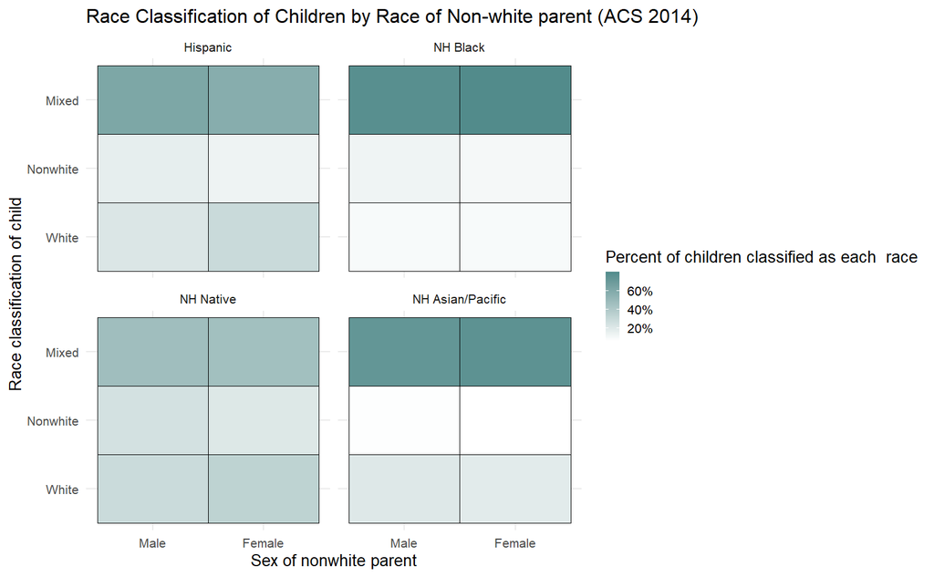

```r
kids %>% group_by(RACETH, SEXF) %>% count(KID, wt = PERWT) %>% mutate(TOTAL = sum(n)) %>%
  ggplot(aes(x = SEXF, y = KID, fill = n/TOTAL)) +
  geom_tile(color = "black") +
  scale_fill_gradient(low = "white", high = "darkslategray4", labels = scales::percent) +
  theme_minimal(base_size = 20) +
  facet_wrap(vars(RACETH)) +
  labs(x = "Sex of nonwhite parent", y = "Race classification of child", fill = "Percent of children classified as each  race", title = "Race Classification of Children by Race of Non-white parent (ACS 2014)")
```

Make the same type of heat map, but using whether or not the nonwhite parent is the householder rather than sex of nonwhite parent.

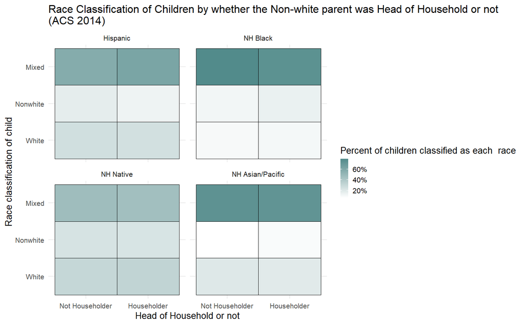

```r
kids %>% group_by(RACETH, HHOLDER) %>% count(KID, wt = PERWT) %>% mutate(TOTAL = sum(n)) %>%
  ggplot(aes(x = HHOLDER, y = KID, fill = n/TOTAL)) +
  geom_tile(color = "black") +
  scale_fill_gradient(low = "white", high = "darkslategray4", labels = scales::percent) +
  theme_minimal(base_size = 20) +
  facet_wrap(vars(RACETH)) +
  labs(x = "Head of Household or not", y = "Race classification of child", fill = "Percent of children classified as each  race", title = "Race Classification of Children by whether the Non-white parent was Head of Household or not\n(ACS 2014)")
```